# Mass Shooting

### Crosstab

```r
source("C:/Users/Chris/Desktop/DataVisualization/DV_TProject1/01 Data/Shooting_CrossTab.R", echo = TRUE)
```

```
##
## > require("jsonlite")
##
## > require("RCurl")
##
## > require(ggplot2)
##
## > require(dplyr)
##
## > require(tidyr)
##
## > KPI_High_Max_value = 0.6666
##
## > KPI_Medium_Max_value = 0.4
##
## > df <- data.frame(fromJSON(getURL(URLencode(gsub("\n",
## +     " ", "skipper.cs.utexas.edu:5001/rest/native/?query=\n                                  ..." ... [TRUNCATED]
##
## > View(df)
##
## > spread(df, RACE, SUM_TOTAL) %>% View
##
## > ggplot() + coord_cartesian() + scale_x_discrete() +
## +     labs(title = "Shootings Crosstab\nSUM_TOTAL") + labs(x = paste("RACE(group)"),
## +     y = .... [TRUNCATED]
```

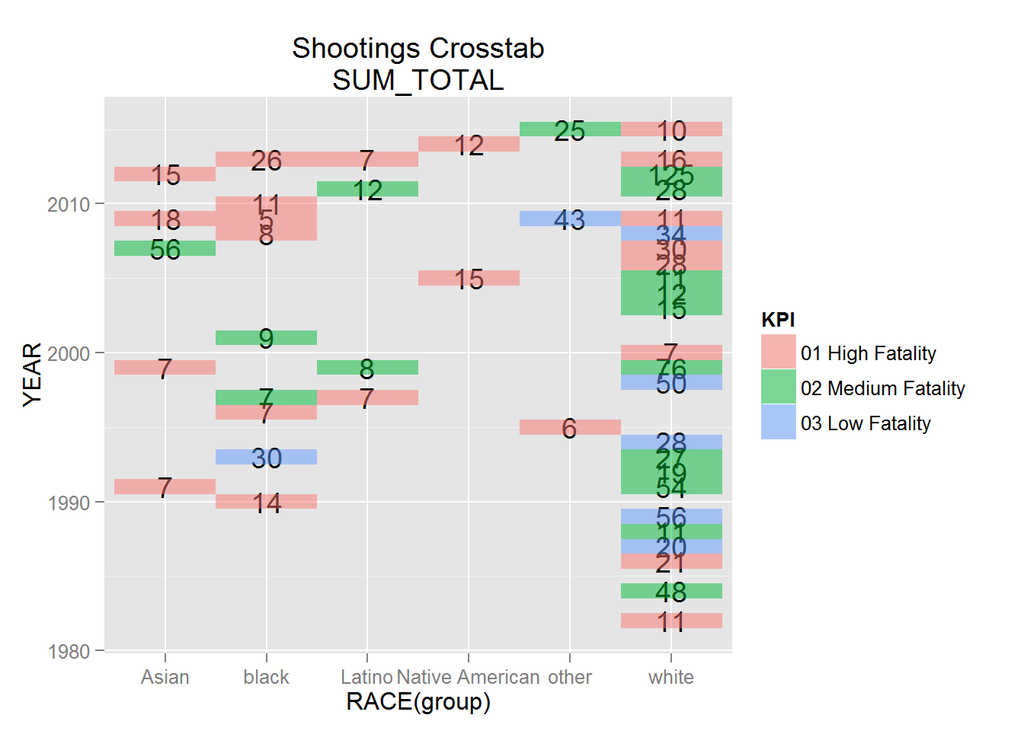

‘’’ This crosstab demonstrates the distribution of total victims based of the perpetrators’ races through the years from 1982 to 2015. The color indicates the percentage of victims that became fatalities. An observation that can be made is the slow increase in other races presence in these visualizations in contrast to the predominant white perpetrators.

We found interesting that how this correlates with the decrease in prejudice in minorities groups, and the increase diversity of the perpetrators shootings. ‘’’

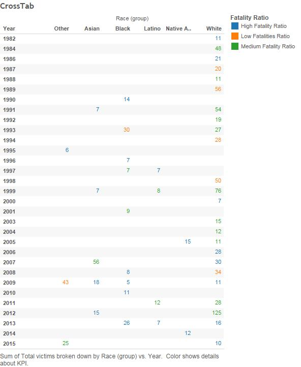